# Lab #4

Armando Castillo

10/12/2020

### Loading the Data

```r
library(readxl)
library(ggplot2)
library(tidyverse)
library(dplyr)
defense <- read_excel('./cyclonesFootball2019.xlsx', sheet='Defensive')
offense <- read_excel('./cyclonesFootball2019.xlsx', sheet='Offensive')
bio <- read_excel('./cyclonesFootball2019.xlsx', sheet='Biography')
```

## Part One: Cleaning the Data

### Although the three Excel sheets are loaded into R, they are not useful before some cleaning. Manipulate the three imported data frames, so that in the cleaned dataset:

### 1. The player names and opponent names are factors.

```r
defClean <- defense %>%
  mutate_at(c('Name', 'Opponent_Opponent'), factor)
offClean <- offense %>%
  mutate_at(c('Name', 'Opponent_Opponent'), factor)
bioClean <- bio %>%
  mutate_at(c('Name'), factor)
```

### 2. All offensive and defensive statistics are numerical. The Weight column in biogrpahy is also numeric. (Optional: Learn to mutate multiple columns systematically using the ?across function in `dplyr)

```r
defClean <- defClean %>%
  mutate(across(where(is.character), as.numeric)) %>%
  mutate_at(c(3:11), ~replace(., is.na(.), 0))
offClean <- offClean %>%
  mutate(across(where(is.character), as.numeric)) %>%
  mutate_at(c(3:12), ~replace(., is.na(.), 0))
bioClean <- bioClean %>%
  mutate(across(starts_with("Weight"), as.numeric))


str(defClean)
```

```
## tibble [502 x 11] (S3: tbl_df/tbl/data.frame)
##  $ Name             : Factor w/ 43 levels "Akers, Landen",..: 40 40 40 40 40 40 40 40 40 40 ...
##  $ Opponent_Opponent: Factor w/ 13 levels "Baylor","Iowa",..: 12 2 11 1 8 13 10 7 6 9 ...
##  $ Tackles_Solo     : num [1:502] 4 4 3 4 3 1 7 3 6 5 ...
##  $ Tackles_ASST     : num [1:502] 4 7 5 2 2 1 1 2 1 5 ...
##  $ Tackles_TFL      : num [1:502] 0 0 0 0 1 0 0 0 1 1 ...
##  $ Tackles_Sack     : num [1:502] 0 0 0 0 0 0 0 0 0 1 ...
##  $ Turnover_FF      : num [1:502] 0 0 0 0 0 0 0 0 0 0 ...
##  $ Turnover_FR      : num [1:502] 0 0 0 0 0 0 0 0 0 0 ...
##  $ Turnover_INT     : num [1:502] 0 0 1 0 0 0 0 0 1 0 ...
##  $ Pass_QBH         : num [1:502] 1 0 0 0 0 0 0 0 1 0 ...
##  $ Pass_PB          : num [1:502] 1 2 0 0 0 1 0 0 0 0 ...
```

```r
str(offClean)
```

```
## tibble [195 x 12] (S3: tbl_df/tbl/data.frame)
##  $ Name             : Factor w/ 17 levels "Akers, Landen",..: 1 1 1 1 1 1 1 1 1 1 ...
##  $ Opponent_Opponent: Factor w/ 13 levels "Baylor","Iowa",..: 12 2 11 1 8 13 10 7 6 9 ...
##  $ Rushing_ATT      : num [1:195] 0 0 1 0 0 0 0 0 0 0 ...
##  $ Rushing_YDS      : num [1:195] 0 0 8 0 0 0 0 0 0 0 ...
##  $ Rushing_TD       : num [1:195] 0 0 0 0 0 0 0 0 0 0 ...
##  $ Receiving_REC    : num [1:195] 1 0 0 0 1 0 0 4 0 1 ...
##  $ Receiving_YDS    : num [1:195] 21 0 0 0 32 0 0 39 0 7 ...
##  $ Receiving_TD     : num [1:195] 0 0 0 0 0 0 0 0 0 0 ...
##  $ Passing_CMP-ATT  : num [1:195] 0 0 0 0 0 0 0 0 0 0 ...
##  $ Passing_YDS      : num [1:195] 0 0 0 0 0 0 0 0 0 0 ...
##  $ Passing_TD       : num [1:195] 0 0 0 0 0 0 0 0 0 0 ...
##  $ Passing_INT      : num [1:195] 0 0 0 0 0 0 0 0 0 0 ...
```

```r
str(bioClean)
```

```
## tibble [105 x 7] (S3: tbl_df/tbl/data.frame)
##  $ Name      : Factor w/ 105 levels "Akers, Landen",..: 1 2 3 4 5 6 7 8 9 10 ...
##  $ Position  : chr [1:105] "Wide Receiver" "Tight End" "Wide Receiver" "Placekicker" ...
##  $ Height    : chr [1:105] "6-0" "6-7" "6-5" "6-0" ...
##  $ Weight    : num [1:105] 188 245 204 195 190 235 255 285 300 215 ...
##  $ Class     : chr [1:105] "Redshirt Senior" "Redshirt Senior" "Redshirt Freshman" "Redshirt Senior" ...
##  $ Hometown  : chr [1:105] "Cedar Rapids, Iowa" "Nixa, Mo." "Seffner, Fla." "Naperville, Ill." ...
##  $ Highschool: chr [1:105] "Washington" "Nixa" "Armwood" "Central" ...
```

### 3. Change the Height column in biogrpahy into numeric. (Hint: Use a unit that works well)

```r
bioClean <- bioClean%>%
   separate(Height, c('feet','inches'), sep='-')%>%
   mutate_at(c(3:4), as.numeric)
bioClean <- bioClean%>%
  mutate(Height = feet*12 + inches)%>%
  select(-c('feet','inches'))%>%
  select(1:2, Height, everything())


str(defClean)
```

```
## tibble [502 x 11] (S3: tbl_df/tbl/data.frame)
##  $ Name             : Factor w/ 43 levels "Akers, Landen",..: 40 40 40 40 40 40 40 40 40 40 ...
##  $ Opponent_Opponent: Factor w/ 13 levels "Baylor","Iowa",..: 12 2 11 1 8 13 10 7 6 9 ...
##  $ Tackles_Solo     : num [1:502] 4 4 3 4 3 1 7 3 6 5 ...
##  $ Tackles_ASST     : num [1:502] 4 7 5 2 2 1 1 2 1 5 ...
##  $ Tackles_TFL      : num [1:502] 0 0 0 0 1 0 0 0 1 1 ...
##  $ Tackles_Sack     : num [1:502] 0 0 0 0 0 0 0 0 0 1 ...
##  $ Turnover_FF      : num [1:502] 0 0 0 0 0 0 0 0 0 0 ...
##  $ Turnover_FR      : num [1:502] 0 0 0 0 0 0 0 0 0 0 ...
##  $ Turnover_INT     : num [1:502] 0 0 1 0 0 0 0 0 1 0 ...
##  $ Pass_QBH         : num [1:502] 1 0 0 0 0 0 0 0 1 0 ...
##  $ Pass_PB          : num [1:502] 1 2 0 0 0 1 0 0 0 0 ...
```

```r
str(offClean)
```

```
## tibble [195 x 12] (S3: tbl_df/tbl/data.frame)
##  $ Name             : Factor w/ 17 levels "Akers, Landen",..: 1 1 1 1 1 1 1 1 1 1 ...
##  $ Opponent_Opponent: Factor w/ 13 levels "Baylor","Iowa",..: 12 2 11 1 8 13 10 7 6 9 ...
##  $ Rushing_ATT      : num [1:195] 0 0 1 0 0 0 0 0 0 0 ...
##  $ Rushing_YDS      : num [1:195] 0 0 8 0 0 0 0 0 0 0 ...
##  $ Rushing_TD       : num [1:195] 0 0 0 0 0 0 0 0 0 0 ...
##  $ Receiving_REC    : num [1:195] 1 0 0 0 1 0 0 4 0 1 ...
##  $ Receiving_YDS    : num [1:195] 21 0 0 0 32 0 0 39 0 7 ...
##  $ Receiving_TD     : num [1:195] 0 0 0 0 0 0 0 0 0 0 ...
##  $ Passing_CMP-ATT  : num [1:195] 0 0 0 0 0 0 0 0 0 0 ...
##  $ Passing_YDS      : num [1:195] 0 0 0 0 0 0 0 0 0 0 ...
##  $ Passing_TD       : num [1:195] 0 0 0 0 0 0 0 0 0 0 ...
##  $ Passing_INT      : num [1:195] 0 0 0 0 0 0 0 0 0 0 ...
```

```r
str(bioClean)
```

```
## tibble [105 x 7] (S3: tbl_df/tbl/data.frame)
##  $ Name      : Factor w/ 105 levels "Akers, Landen",..: 1 2 3 4 5 6 7 8 9 10 ...
##  $ Position  : chr [1:105] "Wide Receiver" "Tight End" "Wide Receiver" "Placekicker" ...
##  $ Height    : num [1:105] 72 79 77 72 72 75 74 74 72 78 ...
##  $ Weight    : num [1:105] 188 245 204 195 190 235 255 285 300 215 ...
##  $ Class     : chr [1:105] "Redshirt Senior" "Redshirt Senior" "Redshirt Freshman" "Redshirt Senior" ...
##  $ Hometown  : chr [1:105] "Cedar Rapids, Iowa" "Nixa, Mo." "Seffner, Fla." "Naperville, Ill." ...
##  $ Highschool: chr [1:105] "Washington" "Nixa" "Armwood" "Central" ...
```

### By cleaning the three data frames in R, at the end of this step you should have the following three clean data frames: defClean, offClean, and bioClean. Print the structures of these data frames.

### Part Two: Tidying

For the following questions, work on the cleaned data frames defClean, offClean, and bioClean.

### 1. Reformat the defClean data frame into a tidy format using pivot_longer. The type of statistic (Tackles_Solo, Tackles_ASST, etc) is added as a new key column named stat.

```r
defClean <- defClean %>%
  pivot_longer(Tackles_Solo:Pass_PB, names_to = 'stat')
```

### 2. Compare the distributions of the defensive statistics. What defensive skills are rare?

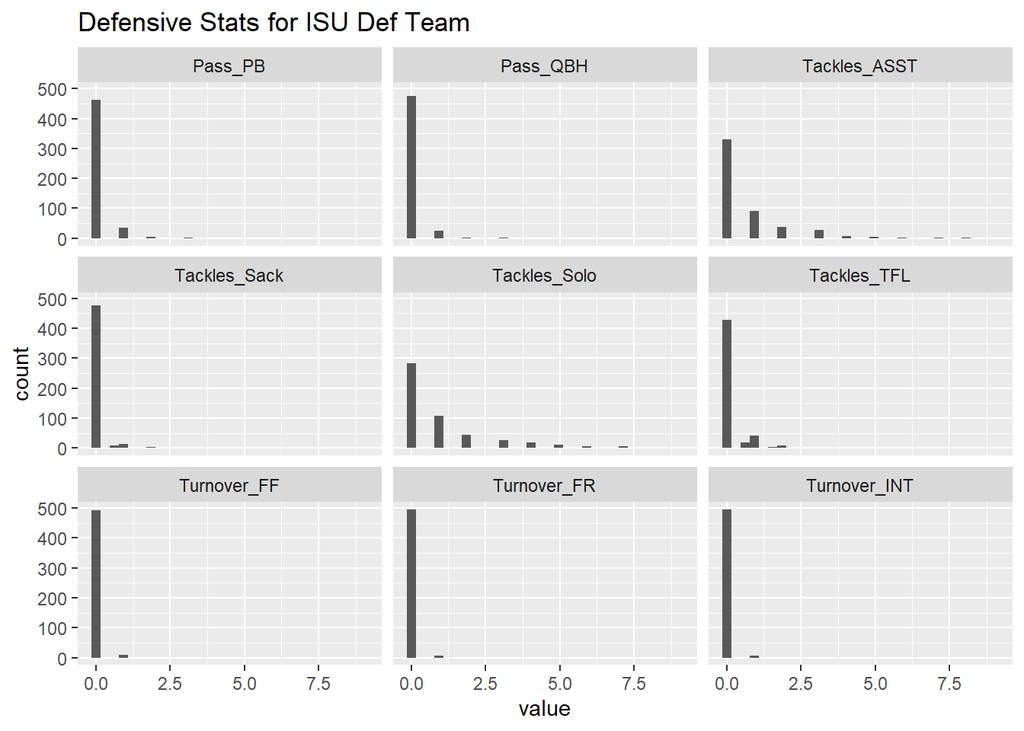

```r
defClean %>%
  ggplot(aes(value)) + geom_histogram() +facet_wrap(~stat) +
  labs(title="Defensive Stats for ISU Def Team")
```

### Answer: Some of the defensive skills that are rare are tackles_sack, turnover_ff, turnover_fr and turover_int as well as pass_pb.

### 3. Did ISU have better defense against Iowa or Notre Dame? Answer this question by creating a scatterplot with x- and y-axes being the number of solo tackles (of each player). A large number of solo tackles is an indicator of good defense.

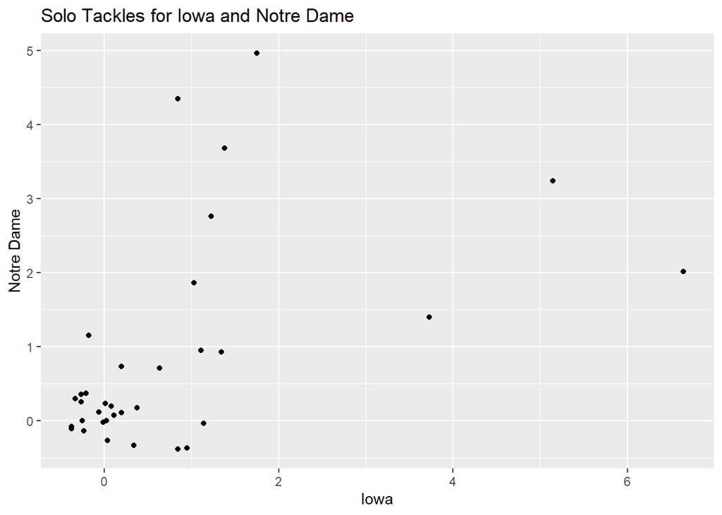

```r
defClean %>%
  filter((Opponent_Opponent == 'Iowa' | Opponent_Opponent == 'Notre Dame') & stat == 'Tackles_Solo') %>%
  pivot_wider(names_from = 'Opponent_Opponent', values_from = 'value') %>%
  select(Name, 'Iowa', 'Notre Dame') %>%
  ggplot(aes(`Iowa`, `Notre Dame`)) +
  geom_jitter() +
  ggtitle('Solo Tackles for Iowa and Notre Dame')
```

### Answer: Iowa state has better defense against Notre Dame because more players from the team have higher solo tackles against Notre dame relative to University of Iowa

### Now turn our attention to the player biography.

### 4. Separate the Hometown column into two columns, namely the city and the state. Print the first few rows of these two columns. (Hint: look at the sep= argument of separate)

```r
bioClean <- bioClean%>% separate(Hometown, c('City', 'State'), sep=', ')
head(bioClean)
```

```
## # A tibble: 6 x 8
##   Name         Position     Height Weight Class       City      State Highschool
##   <fct>        <chr>         <dbl>  <dbl> <chr>       <chr>     <chr> <chr>
## 1 Akers, Land~ Wide Receiv~     72    188 Redshirt S~ Cedar Ra~ Iowa  Washington
## 2 Allen, Chase Tight End        79    245 Redshirt S~ Nixa      Mo.   Nixa
## 3 Anderson, E~ Wide Receiv~     77    204 Redshirt F~ Seffner   Fla.  Armwood
## 4 Assalley, C~ Placekicker      72    195 Redshirt S~ Napervil~ Ill.  Central
## 5 Azunna, Arn~ Defensive B~     72    190 Redshirt S~ Grand Pr~ Texas Lake Ridge
## 6 Bailey, Cor~ Defensive E~     75    235 Redshirt J~ Clarksda~ Miss. Clarksdale
```

### 5. How many players are there from each state?

```r
bioClean %>%
  group_by(State) %>%
  summarise(nState=n()) %>%
  arrange(desc(nState))
```

```
## # A tibble: 19 x 2
##    State     nState
##    <chr>      <int>
##  1 Iowa          35
##  2 Fla.          10
##  3 Ohio           7
##  4 Mo.            6
##  5 Texas          6
##  6 Wis.           6
##  7 Ill.           5
##  8 Ariz.          4
##  9 Ga.            4
## 10 Mich.          4
## 11 Minn.          4
## 12 Calif.         3
## 13 Kan.           3
## 14 Okla.          2
## 15 S.D.           2
## 16 Ark.           1
## 17 Australia      1
## 18 Miss.          1
## 19 Pa.            1
```

### Answer: Iowa has the most players with a grand total of 35.

### Part Three: Joining Data Frames

### 1. Find which states do the ISU defensive and offensive players come from. Create an appropriate summary.

```r
offState <- offClean %>%
  select(Name) %>%
  distinct() %>%
  left_join(bioClean, by=c("Name"))
offState %>%
  group_by(State) %>%
  drop_na() %>%
  summarise(nState=n()) %>%
  arrange(desc(nState))
```

```
## # A tibble: 11 x 2
##    State nState
##    <chr>  <int>
##  1 Fla.       2
##  2 Okla.      2
##  3 Ariz.      1
##  4 Ark.       1
##  5 Ga.        1
##  6 Ill.       1
##  7 Iowa       1
##  8 Kan.       1
##  9 Mo.        1
## 10 Ohio       1
## 11 Texas      1
```

```r
defState <- defClean %>%
  pivot_wider(names_from='stat', values_from='value') %>%
  select(Name) %>%
  distinct() %>%
  left_join(bioClean, by=c("Name"))
defState %>%
  group_by(State) %>%
  drop_na() %>%
  summarise(nState=n()) %>%
  arrange(desc(nState))
```

```
## # A tibble: 12 x 2
##    State  nState
##    <chr>   <int>
##  1 Iowa        7
##  2 Fla.        4
##  3 Ga.         3
##  4 Ohio        3
##  5 Calif.      2
##  6 Mo.         2
##  7 Okla.       2
##  8 Texas       2
##  9 Wis.        2
## 10 Ark.        1
## 11 Kan.        1
## 12 Mich.       1
```

### 2. How does the performance of quarterback Brock Purdy relate to the performance of the ISU team?

```r
Purdy <- offClean %>% filter(Name == "Purdy, Brock")
summary(Purdy)
```

```
##                   Name       Opponent_Opponent  Rushing_ATT
##  Purdy, Brock       :13   Baylor      :1       Min.   : 2.000
##  Akers, Landen      : 0   Iowa        :1       1st Qu.: 4.000
##  Allen, Chase       : 0   Kansas      :1       Median : 6.000
##  Brock, Jirehl      : 0   Kansas State:1       Mean   : 7.154
##  Croney Jr., Sheldon: 0   Notre Dame  :1       3rd Qu.: 9.000
##  Hall, Breece       : 0   Oklahoma    :1       Max.   :15.000
##  (Other)            : 0   (Other)     :7
##   Rushing_YDS       Rushing_TD     Receiving_REC Receiving_YDS  Receiving_TD
##  Min.   :-16.00   Min.   :0.0000   Min.   :0     Min.   :0     Min.   :0
##  1st Qu.: -3.00   1st Qu.:0.0000   1st Qu.:0     1st Qu.:0     1st Qu.:0
##  Median :  7.00   Median :0.0000   Median :0     Median :0     Median :0
##  Mean   : 19.15   Mean   :0.6154   Mean   :0     Mean   :0     Mean   :0
##  3rd Qu.: 34.00   3rd Qu.:1.0000   3rd Qu.:0     3rd Qu.:0     3rd Qu.:0
##  Max.   :102.00   Max.   :3.0000   Max.   :0     Max.   :0     Max.   :0
##
##  Passing_CMP-ATT  Passing_YDS      Passing_TD     Passing_INT
##  Min.   :0       Min.   :185.0   Min.   :0.000   Min.   :0.0000
##  1st Qu.:0       1st Qu.:247.0   1st Qu.:1.000   1st Qu.:0.0000
##  Median :0       Median :282.0   Median :2.000   Median :1.0000
##  Mean   :0       Mean   :306.3   Mean   :2.077   Mean   :0.6923
##  3rd Qu.:0       3rd Qu.:372.0   3rd Qu.:3.000   3rd Qu.:1.0000
##  Max.   :0       Max.   :435.0   Max.   :5.000   Max.   :3.0000
##
```

```r
summary(offClean)
```

```
##                Name          Opponent_Opponent  Rushing_ATT
##  Akers, Landen   : 13   TCU           : 17     Min.   : 0.000
##  Allen, Chase    : 13   ULM           : 17     1st Qu.: 0.000
##  Jones, Deshaunte: 13   West Virginia : 16     Median : 0.000
##  Kolar, Charlie  : 13   Baylor        : 15     Mean   : 2.051
##  Milton, Tarique : 13   Kansas        : 15     3rd Qu.: 1.000
##  Nwangwu, Kene   : 13   Oklahoma State: 15     Max.   :28.000
##  (Other)         :117   (Other)       :100
##   Rushing_YDS        Rushing_TD     Receiving_REC    Receiving_YDS
##  Min.   :-16.000   Min.   :0.0000   Min.   : 0.000   Min.   :  0.00
##  1st Qu.:  0.000   1st Qu.:0.0000   1st Qu.: 0.000   1st Qu.:  0.00
##  Median :  0.000   Median :0.0000   Median : 1.000   Median :  4.00
##  Mean   :  8.995   Mean   :0.1128   Mean   : 1.615   Mean   : 20.75
##  3rd Qu.:  0.000   3rd Qu.:0.0000   3rd Qu.: 2.000   3rd Qu.: 30.50
##  Max.   :183.000   Max.   :3.0000   Max.   :14.000   Max.   :144.00
##
##   Receiving_TD    Passing_CMP-ATT  Passing_YDS       Passing_TD
##  Min.   :0.0000   Min.   :0       Min.   :  0.00   Min.   :0.0000
##  1st Qu.:0.0000   1st Qu.:0       1st Qu.:  0.00   1st Qu.:0.0000
##  Median :0.0000   Median :0       Median :  0.00   Median :0.0000
##  Mean   :0.1487   Mean   :0       Mean   : 20.75   Mean   :0.1487
##  3rd Qu.:0.0000   3rd Qu.:0       3rd Qu.:  0.00   3rd Qu.:0.0000
##  Max.   :2.0000   Max.   :0       Max.   :435.00   Max.   :5.0000
##
##   Passing_INT
##  Min.   :0.00000
##  1st Qu.:0.00000
##  Median :0.00000
##  Mean   :0.04615
##  3rd Qu.:0.00000
##  Max.   :3.00000
##
```

```r
dat1 <- offClean %>%
  group_by(Opponent_Opponent)%>%
  summarise(Rushing_YDS = sum(Rushing_YDS, na.rm = TRUE), Rushing_TD = sum(Rushing_TD, na.rm = TRUE))
datPurdy <- offClean %>%
  filter(Name == 'Purdy, Brock') %>%
  select(Opponent_Opponent, Passing_YDS)
datPurdyxTeam <- dat1 %>%
  left_join(datPurdy)
print(datPurdyxTeam)
```

```
## # A tibble: 13 x 4
##    Opponent_Opponent Rushing_YDS Rushing_TD Passing_YDS
##    <fct>                   <dbl>      <dbl>       <dbl>
##  1 Baylor                     63          1         342
##  2 Iowa                       91          0         276
##  3 Kansas                    118          2         372
##  4 Kansas State               56          1         185
##  5 Notre Dame                 45          0         222
##  6 Oklahoma                  197          1         282
##  7 Oklahoma State             86          2         382
##  8 TCU                       193          4         247
##  9 Texas                     114          0         354
## 10 Texas Tech                186          2         378
## 11 ULM                       274          4         435
## 12 UNI                       185          1         278
## 13 West Virginia             146          4         229
```

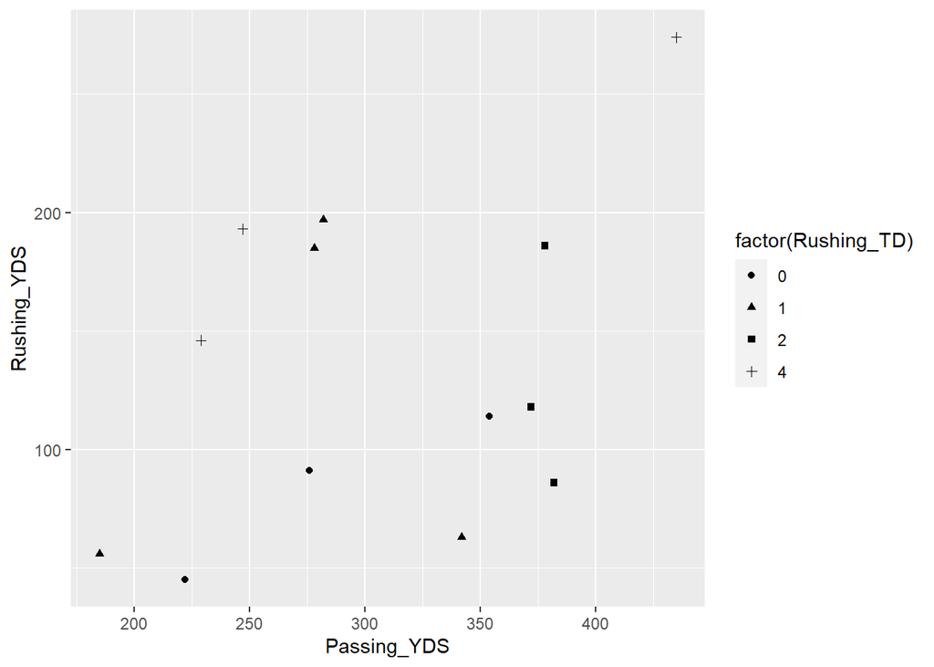

```r
ggplot(datPurdyxTeam, aes(x = Passing_YDS, Rushing_YDS, shape = factor(Rushing_TD))) + geom_point(na.rm=TRUE)
```

### Answer: I first start by comparing the basic stats of Brock to the rest of the team by using the summary functions. We can see that he has a higher passing touchdown than the team which shows he outpferoms the team. I then look at the correlation between passing yards and rushing yards. We can see that there is a positive relationship and he performs at a very high level

### 3. Which ISU player(s) made big progress over the last year? Compare the 2019 and the 2018 data here.

```r
defense2 <- read_excel('./cyclonesFootball2018.xlsx', sheet='Defensive')
offense2 <- read_excel('./cyclonesFootball2018.xlsx', sheet='Offensive')



defClean2 <- defense2 %>% mutate(Tackles_Solo = as.numeric(Tackles_Solo))
offClean2 <- offense2 %>% mutate(Receiving_YDS = as.numeric(Receiving_YDS))
offRec <- inner_join(offClean, offClean2, by='Name') %>%
           mutate(Receiving_YDS_Diff = Receiving_YDS.x - Receiving_YDS.y) %>%
           select(Name, Receiving_YDS_Diff) %>%
           arrange(-Receiving_YDS_Diff)
offRec
```

```
## # A tibble: 1,223 x 2
##    Name             Receiving_YDS_Diff
##    <chr>                         <dbl>
##  1 Jones, Deshaunte                144
##  2 Milton, Tarique                 144
##  3 Milton, Tarique                 144
##  4 Milton, Tarique                 142
##  5 Milton, Tarique                 142
##  6 Milton, Tarique                 141
##  7 Jones, Deshaunte                140
##  8 Milton, Tarique                 139
##  9 Jones, Deshaunte                138
## 10 Milton, Tarique                 130
## # ... with 1,213 more rows
```

```r
defClean2 <- defense %>% mutate(Tackles_Solo = as.numeric(Tackles_Solo))
defClean3 <- defense2 %>% mutate(Tackles_Solo = as.numeric(Tackles_Solo))
deftac<- inner_join(defClean2, defClean3, by='Name') %>%
           mutate(Tackles_Solo_Diff = Tackles_Solo.x - Tackles_Solo.y) %>%
           select(Name, Tackles_Solo_Diff) %>%
           arrange(-Tackles_Solo_Diff)
deftac
```

```
## # A tibble: 3,264 x 2
##    Name              Tackles_Solo_Diff
##    <chr>                         <dbl>
##  1 Lewis, Braxton                    9
##  2 Lewis, Braxton                    9
##  3 Lewis, Braxton                    8
##  4 Lewis, Braxton                    7
##  5 Lewis, Braxton                    7
##  6 Lewis, Braxton                    7
##  7 Lewis, Braxton                    7
##  8 Lewis, Braxton                    7
##  9 Johnson , Anthony                 7
## 10 Johnson , Anthony                 7
## # ... with 3,254 more rows
```

### Answer: I compared the receiving yards and the tackes to get an idea for both offenseive and defensive performance. We can see that Lewis and Johnson have imporved significally. On the offense we can see Jones and Milton have have also upped their game and improved.